# Лабораторная работа №7

Расширенные настройки межсетевого экрана

Устинова В. В.

Российский университет дружбы народов, Москва, Россия

17 октября 2026

# Информация

## Докладчик

- Устинова Виктория Вадимовна
- студент НПИбд-01-24
- Российский университет дружбы народов

# Вводная часть

## Цель

Получить навыки настройки межсетевого экрана в Linux в части переадресации портов и настройки Masquerading.

## Задание

1. Настройте межсетевой экран виртуальной машины server для доступа к серверу по протоколу SSH не через 22-й порт, а через порт 2022 (см. разделы 7.4.1 и 7.4.2).
2. Настройте Port Forwarding на виртуальной машине server (см. разделы 7.4.3).
3. Настройте маскарадинг на виртуальной машине server для организации доступа клиента к сети Интернет (см. раздел 7.4.3).
4. Напишите скрипт для Vagrant, фиксирующий действия по расширенной настройке межсетевого экрана. Соответствующим образом внести изменения в Vagrantfile (см. раздел 7.4.4).

# Выполнение лабораторной работы

## Создание файла службы ssh-custom

На основе системного файла описания службы ssh создан файл `/etc/firewalld/services/ssh-custom.xml` и выведено его содержимое. Файл состоит из XML-декларации и элемента `<service>` с именем `<short>`, описанием `<description>` и портом `<port>`.

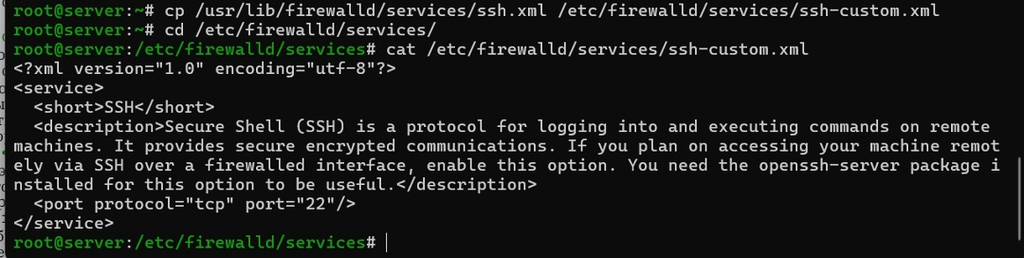

Копирование файла описания службы ssh в ssh-custom.xml и просмотр его содержимого

## Редактирование ssh-custom.xml

Порт 22 заменён на 2022, имя службы изменено на SSH-custom, в описании указано, что это модифицированный файл службы.

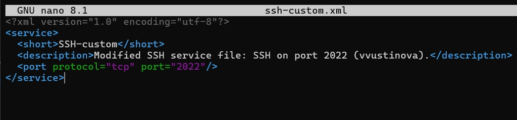

Отредактированный файл ssh-custom.xml с портом 2022

## Список доступных служб

Выведен список доступных служб командой `firewall-cmd --get-services`.

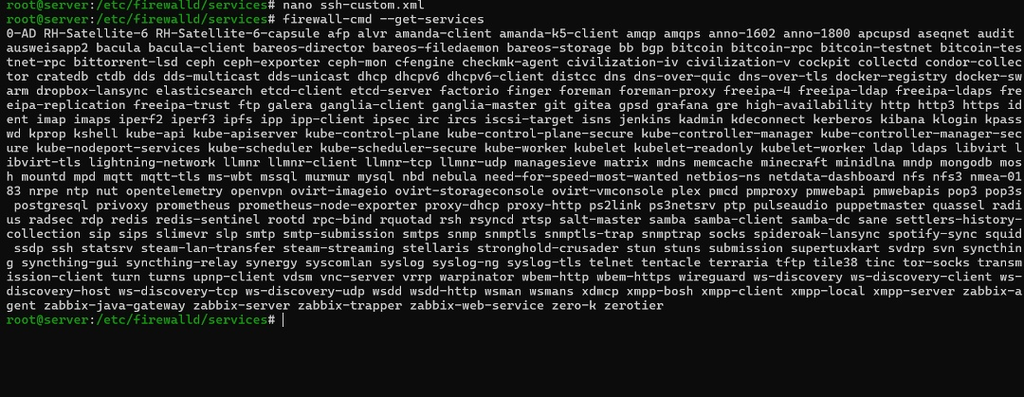

Список доступных служб: служба ssh-custom ещё не отображается

## Список служб после перезагрузки правил

После перезагрузки правил межсетевого экрана повторно выведены список доступных служб и список активных служб.

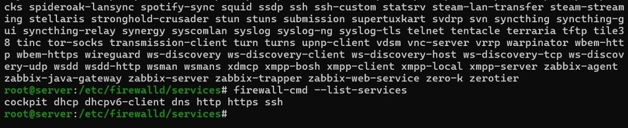

Служба ssh-custom есть в списке доступных, но не активирована

## Добавление службы ssh-custom

Служба ssh-custom добавлена в FirewallD, затем добавлена в постоянную конфигурацию, и правила перезагружены.

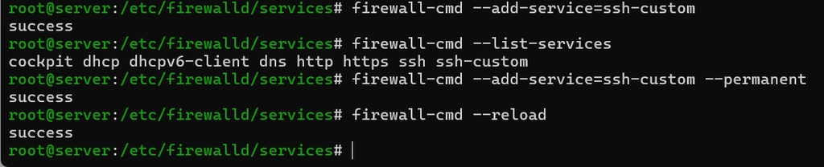

Служба ssh-custom добавлена в список активных служб

## Подключение по SSH через порт 2022

На сервере настроена переадресация с порта 2022 на порт 22. С клиента выполнено подключение по SSH к серверу через порт 2022.

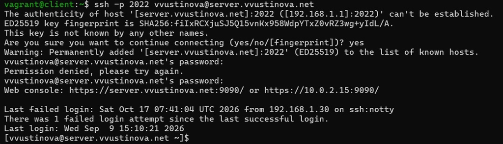

Успешное подключение с клиента к серверу по SSH через порт 2022

## Проверка перенаправления пакетов

На сервере проверено, активировано ли в ядре перенаправление IPv4-пакетов, командой `sysctl -a | grep forward`.

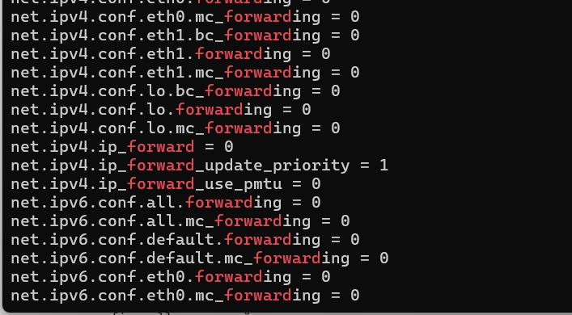

Параметр net.ipv4.ip_forward равен 0, перенаправление выключено

## Включение перенаправления и маскарадинга

Включено перенаправление IPv4-пакетов через файл `/etc/sysctl.d/90-forward.conf`, включён маскарадинг в зоне public, и правила перезагружены.

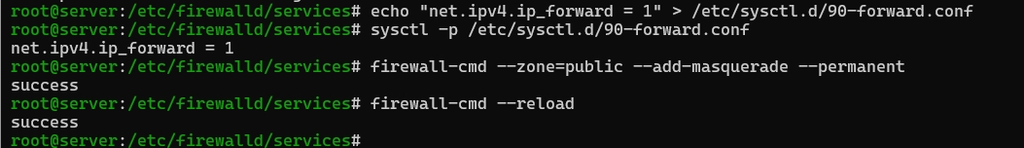

Включение перенаправления IPv4-пакетов и маскарадинга на сервере

## Проверка доступа клиента в Интернет

На клиенте проверена доступность сети Интернет командой `ping`.

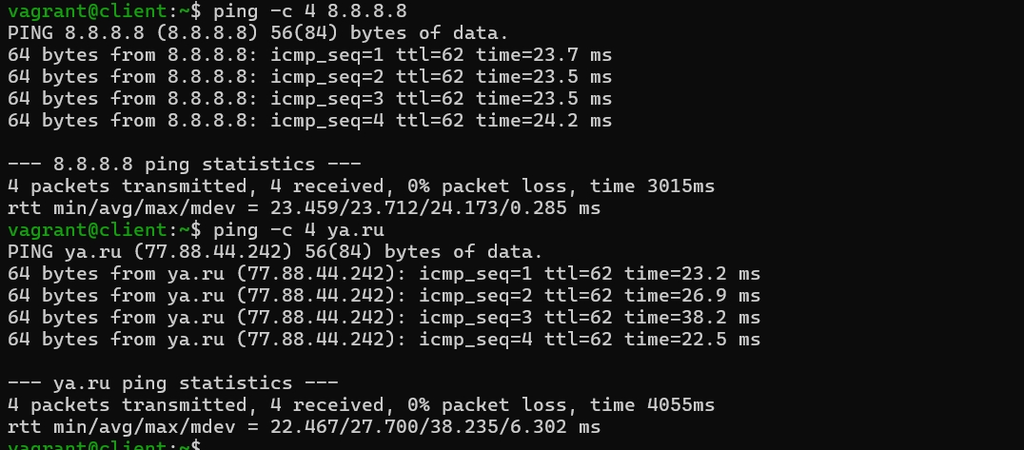

Клиент получает ответы от 8.8.8.8 и ya.ru без потерь пакетов

## Подготовка файлов для provision

На сервере в каталоге `/vagrant/provision/server` создан каталог firewall, в соответствующие подкаталоги скопированы конфигурационные файлы, создан исполняемый файл `firewall.sh`.

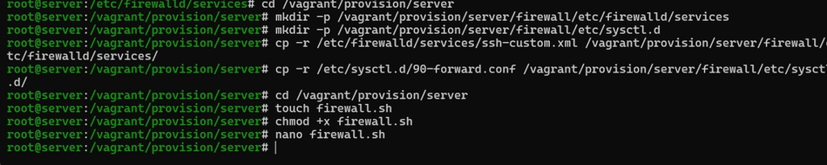

Создание каталогов, копирование файлов ssh-custom.xml и 90-forward.conf, создание firewall.sh

## Скрипт firewall.sh

В файл `firewall.sh` записан скрипт, который копирует конфигурационные файлы, добавляет службу ssh-custom, переадресацию порта 2022 на 22 и маскарадинг, после чего перезагружает правила.

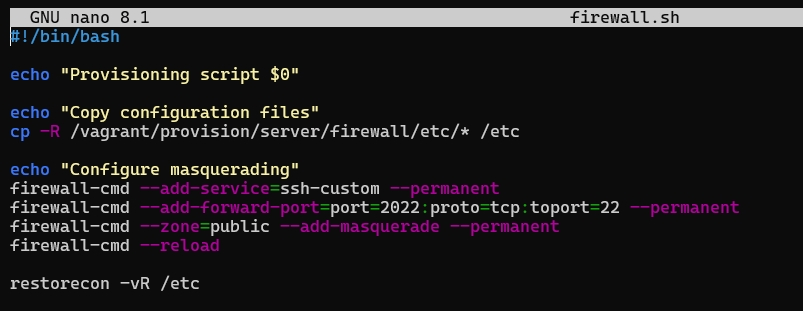

Скрипт firewall.sh

## Изменения в Vagrantfile

Для отработки скрипта при загрузке виртуальной машины в Vagrantfile в конфигурацию сервера добавлена запись provision «server firewall».

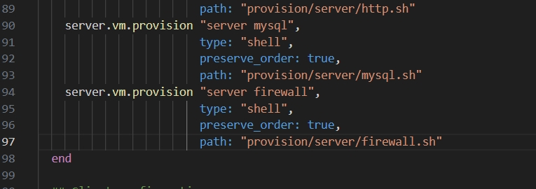

Запись server firewall в Vagrantfile

# Заключение

## Выводы

В ходе работы получены навыки настройки межсетевого экрана в Linux в части переадресации портов и маскарадинга. Создана пользовательская служба ssh-custom, настроен доступ к серверу по SSH через порт 2022, включены перенаправление IPv4-пакетов и маскарадинг для выхода клиента в Интернет. Действия по настройке зафиксированы в скрипте `firewall.sh` и подключены в Vagrantfile.